# Risk Factor Analysis

## Outcome Variable

**Outcome Variable:** whz

## Predictor Variables

**Intervention Variable:** rain_quartile

**Adjustment Set:**

unadjusted

## Stratifying Variables

The analysis was stratified on these variable(s):

- studyid
- country

## Data Summary

| studyid | country | rain_quartile | n_cell | n |
| --- | --- | --- | --- | --- |
| CMC-V-BCS-2002 | India | Opposite max rain | 2177 | 8701 |
| CMC-V-BCS-2002 | India | Post-max rain | 2205 | 8701 |
| CMC-V-BCS-2002 | India | Pre-max rain | 2142 | 8701 |
| CMC-V-BCS-2002 | India | Max rain | 2177 | 8701 |
| CMIN | Bangladesh | Opposite max rain | 1284 | 5372 |
| CMIN | Bangladesh | Post-max rain | 1378 | 5372 |
| CMIN | Bangladesh | Pre-max rain | 1336 | 5372 |
| CMIN | Bangladesh | Max rain | 1374 | 5372 |
| CMIN | Peru | Opposite max rain | 3186 | 12078 |
| CMIN | Peru | Post-max rain | 3157 | 12078 |
| CMIN | Peru | Pre-max rain | 3181 | 12078 |
| CMIN | Peru | Max rain | 2554 | 12078 |
| CONTENT | Peru | Opposite max rain | 2150 | 8339 |
| CONTENT | Peru | Post-max rain | 2136 | 8339 |
| CONTENT | Peru | Pre-max rain | 2023 | 8339 |
| CONTENT | Peru | Max rain | 2030 | 8339 |
| EE | Pakistan | Opposite max rain | 1676 | 6363 |
| EE | Pakistan | Post-max rain | 1143 | 6363 |
| EE | Pakistan | Pre-max rain | 2049 | 6363 |
| EE | Pakistan | Max rain | 1495 | 6363 |
| GMS-Nepal | Nepal | Opposite max rain | 3320 | 12712 |
| GMS-Nepal | Nepal | Post-max rain | 3404 | 12712 |
| GMS-Nepal | Nepal | Pre-max rain | 2953 | 12712 |
| GMS-Nepal | Nepal | Max rain | 3035 | 12712 |
| Guatemala BSC | Guatemala | Opposite max rain | 616 | 2545 |
| Guatemala BSC | Guatemala | Post-max rain | 651 | 2545 |
| Guatemala BSC | Guatemala | Pre-max rain | 591 | 2545 |
| Guatemala BSC | Guatemala | Max rain | 687 | 2545 |
| IRC | India | Opposite max rain | 2436 | 9729 |
| IRC | India | Post-max rain | 2490 | 9729 |
| IRC | India | Pre-max rain | 2345 | 9729 |
| IRC | India | Max rain | 2458 | 9729 |
| MAL-ED | Bangladesh | Opposite max rain | 1401 | 5523 |
| MAL-ED | Bangladesh | Post-max rain | 1393 | 5523 |
| MAL-ED | Bangladesh | Pre-max rain | 1359 | 5523 |
| MAL-ED | Bangladesh | Max rain | 1370 | 5523 |
| MAL-ED | Brazil | Opposite max rain | 1151 | 4629 |
| MAL-ED | Brazil | Post-max rain | 1143 | 4629 |
| MAL-ED | Brazil | Pre-max rain | 1164 | 4629 |
| MAL-ED | Brazil | Max rain | 1171 | 4629 |
| MAL-ED | India | Opposite max rain | 1402 | 5602 |
| MAL-ED | India | Post-max rain | 1407 | 5602 |
| MAL-ED | India | Pre-max rain | 1392 | 5602 |
| MAL-ED | India | Max rain | 1401 | 5602 |
| MAL-ED | Nepal | Opposite max rain | 1398 | 5593 |
| MAL-ED | Nepal | Post-max rain | 1404 | 5593 |
| MAL-ED | Nepal | Pre-max rain | 1404 | 5593 |
| MAL-ED | Nepal | Max rain | 1387 | 5593 |
| MAL-ED | Peru | Opposite max rain | 1447 | 5840 |
| MAL-ED | Peru | Post-max rain | 1473 | 5840 |
| MAL-ED | Peru | Pre-max rain | 1474 | 5840 |
| MAL-ED | Peru | Max rain | 1446 | 5840 |
| MAL-ED | South Africa | Opposite max rain | 1493 | 5967 |
| MAL-ED | South Africa | Post-max rain | 1511 | 5967 |
| MAL-ED | South Africa | Pre-max rain | 1504 | 5967 |
| MAL-ED | South Africa | Max rain | 1459 | 5967 |
| MAL-ED | Tanzania | Opposite max rain | 1359 | 5639 |
| MAL-ED | Tanzania | Post-max rain | 1446 | 5639 |
| MAL-ED | Tanzania | Pre-max rain | 1419 | 5639 |
| MAL-ED | Tanzania | Max rain | 1415 | 5639 |
| ResPak | Pakistan | Opposite max rain | 655 | 3109 |
| ResPak | Pakistan | Post-max rain | 590 | 3109 |
| ResPak | Pakistan | Pre-max rain | 803 | 3109 |
| ResPak | Pakistan | Max rain | 1061 | 3109 |
| TanzaniaChild2 | Tanzania | Opposite max rain | 7507 | 29516 |
| TanzaniaChild2 | Tanzania | Post-max rain | 7244 | 29516 |
| TanzaniaChild2 | Tanzania | Pre-max rain | 7333 | 29516 |
| TanzaniaChild2 | Tanzania | Max rain | 7432 | 29516 |

The following strata were considered:

- studyid: CMC-V-BCS-2002, country: India
- studyid: CMIN, country: Bangladesh
- studyid: CMIN, country: Peru
- studyid: CONTENT, country: Peru
- studyid: EE, country: Pakistan
- studyid: GMS-Nepal, country: Nepal
- studyid: Guatemala BSC, country: Guatemala
- studyid: IRC, country: India
- studyid: MAL-ED, country: Bangladesh
- studyid: MAL-ED, country: Brazil
- studyid: MAL-ED, country: India
- studyid: MAL-ED, country: Nepal
- studyid: MAL-ED, country: Peru
- studyid: MAL-ED, country: South Africa
- studyid: MAL-ED, country: Tanzania
- studyid: ResPak, country: Pakistan
- studyid: TanzaniaChild2, country: Tanzania

## Methods Detail

We’re interested in the causal parameters $E[Y_a]$ for all values of $a \in \mathcal{A}$. These parameters represent the mean outcome if, possibly contrary to fact, we intervened to set all units to have $A=a$. Under the randomization and positivity assumptions, these are identified by the statistical parameters $\psi_a=E_W[E_{Y|A,W}(Y|A=a,W)]$. In addition, we’re interested in the mean of $Y$, $E[Y]$ under no intervention (the observed mean). We will estimate these parameters by using SuperLearner to fit the relevant likelihood factors – $E_{Y|A,W}(Y|A=a,W)$ and $p(A=a|W)$, and then updating our likelihood fit using a joint TMLE.

For unadjusted analyses ($W=\{\}$), initial likelihoods were estimated using Lrnr_glm to estimate the simple $E(Y|A)$ and Lrnr_mean to estimate $p(A)$. For adjusted analyses, a small library containing Lrnr_glmnet, Lrnr_xgboost, and Lrnr_mean was used.

Having estimated these parameters, we will then use the delta method to estimate relative risks and attributable risks relative to a prespecified baseline level of $A$.

# Results Detail

## Results Plots

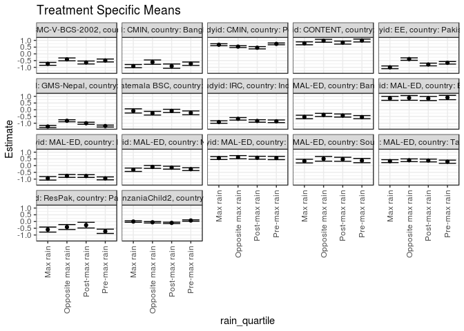

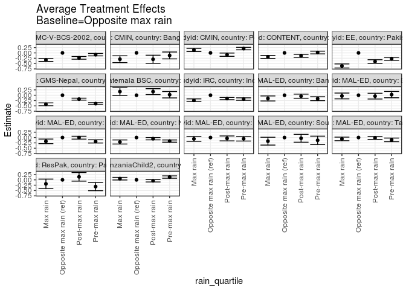

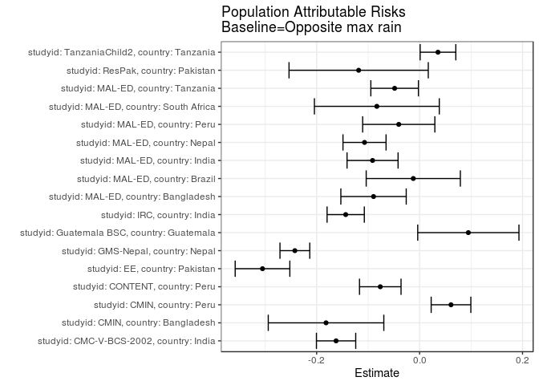

## Results Table

### Parameter: TSM

| studyid | country | intervention_level | baseline_level | estimate | ci_lower | ci_upper |
| --- | --- | --- | --- | --- | --- | --- |
| CMC-V-BCS-2002 | India | Opposite max rain | NA | -0.4087598 | -0.5145390 | -0.3029805 |
| CMC-V-BCS-2002 | India | Post-max rain | NA | -0.6409569 | -0.7498052 | -0.5321086 |
| CMC-V-BCS-2002 | India | Pre-max rain | NA | -0.4912932 | -0.5990709 | -0.3835154 |
| CMC-V-BCS-2002 | India | Max rain | NA | -0.7407763 | -0.8490623 | -0.6324903 |
| CMIN | Bangladesh | Opposite max rain | NA | -0.6135280 | -0.7746471 | -0.4524090 |
| CMIN | Bangladesh | Post-max rain | NA | -0.9119086 | -1.0720185 | -0.7517986 |
| CMIN | Bangladesh | Pre-max rain | NA | -0.7329716 | -0.8600410 | -0.6059022 |
| CMIN | Bangladesh | Max rain | NA | -0.9086754 | -1.0275062 | -0.7898446 |
| CMIN | Peru | Opposite max rain | NA | 0.5390144 | 0.4723480 | 0.6056809 |
| CMIN | Peru | Post-max rain | NA | 0.4552645 | 0.3704580 | 0.5400709 |
| CMIN | Peru | Pre-max rain | NA | 0.7422572 | 0.6759055 | 0.8086088 |
| CMIN | Peru | Max rain | NA | 0.6781441 | 0.6042840 | 0.7520041 |
| CONTENT | Peru | Opposite max rain | NA | 0.9731163 | 0.8665883 | 1.0796443 |
| CONTENT | Peru | Post-max rain | NA | 0.8370646 | 0.7233972 | 0.9507320 |
| CONTENT | Peru | Pre-max rain | NA | 0.9918339 | 0.8852918 | 1.0983760 |
| CONTENT | Peru | Max rain | NA | 0.7838818 | 0.6746891 | 0.8930744 |
| EE | Pakistan | Opposite max rain | NA | -0.3875716 | -0.4792874 | -0.2958558 |
| EE | Pakistan | Post-max rain | NA | -0.7897200 | -0.8903066 | -0.6891335 |
| EE | Pakistan | Pre-max rain | NA | -0.6648902 | -0.7584975 | -0.5712829 |
| EE | Pakistan | Max rain | NA | -0.9988562 | -1.1012538 | -0.8964586 |
| GMS-Nepal | Nepal | Opposite max rain | NA | -0.8179970 | -0.8920923 | -0.7439016 |
| GMS-Nepal | Nepal | Post-max rain | NA | -1.0017098 | -1.0777187 | -0.9257008 |
| GMS-Nepal | Nepal | Pre-max rain | NA | -1.2112191 | -1.2831229 | -1.1393153 |
| GMS-Nepal | Nepal | Max rain | NA | -1.2441977 | -1.3250375 | -1.1633579 |
| Guatemala BSC | Guatemala | Opposite max rain | NA | -0.2560877 | -0.3929840 | -0.1191913 |
| Guatemala BSC | Guatemala | Post-max rain | NA | -0.0868049 | -0.2067583 | 0.0331485 |
| Guatemala BSC | Guatemala | Pre-max rain | NA | -0.2320474 | -0.3741081 | -0.0899867 |
| Guatemala BSC | Guatemala | Max rain | NA | -0.0863173 | -0.2420993 | 0.0694647 |
| IRC | India | Opposite max rain | NA | -0.6754639 | -0.7697086 | -0.5812191 |
| IRC | India | Post-max rain | NA | -0.8327309 | -0.9243528 | -0.7411091 |
| IRC | India | Pre-max rain | NA | -0.8554925 | -0.9531436 | -0.7578415 |
| IRC | India | Max rain | NA | -0.9125753 | -1.0055027 | -0.8196478 |
| MAL-ED | Bangladesh | Opposite max rain | NA | -0.3842470 | -0.5020105 | -0.2664834 |
| MAL-ED | Bangladesh | Post-max rain | NA | -0.4306246 | -0.5451973 | -0.3160518 |
| MAL-ED | Bangladesh | Pre-max rain | NA | -0.5468801 | -0.6631659 | -0.4305943 |
| MAL-ED | Bangladesh | Max rain | NA | -0.5363942 | -0.6653770 | -0.4074113 |
| MAL-ED | Brazil | Opposite max rain | NA | 0.8796742 | 0.7036277 | 1.0557207 |
| MAL-ED | Brazil | Post-max rain | NA | 0.8362117 | 0.6839864 | 0.9884371 |
| MAL-ED | Brazil | Pre-max rain | NA | 0.9083505 | 0.7467580 | 1.0699430 |
| MAL-ED | Brazil | Max rain | NA | 0.8450897 | 0.6973782 | 0.9928012 |
| MAL-ED | India | Opposite max rain | NA | -0.7653994 | -0.8714743 | -0.6593246 |
| MAL-ED | India | Post-max rain | NA | -0.7725302 | -0.8744972 | -0.6705632 |
| MAL-ED | India | Pre-max rain | NA | -0.9461494 | -1.0551135 | -0.8371853 |
| MAL-ED | India | Max rain | NA | -0.9440007 | -1.0732923 | -0.8147091 |
| MAL-ED | Nepal | Opposite max rain | NA | -0.0968312 | -0.2040759 | 0.0104135 |
| MAL-ED | Nepal | Post-max rain | NA | -0.1513568 | -0.2596145 | -0.0430992 |
| MAL-ED | Nepal | Pre-max rain | NA | -0.2625071 | -0.3685036 | -0.1565107 |
| MAL-ED | Nepal | Max rain | NA | -0.3053425 | -0.4312206 | -0.1794643 |
| MAL-ED | Peru | Opposite max rain | NA | 0.6257084 | 0.5055520 | 0.7458648 |
| MAL-ED | Peru | Post-max rain | NA | 0.5847895 | 0.4752151 | 0.6943640 |
| MAL-ED | Peru | Pre-max rain | NA | 0.5673609 | 0.4471631 | 0.6875588 |
| MAL-ED | Peru | Max rain | NA | 0.5634025 | 0.4546741 | 0.6721308 |
| MAL-ED | South Africa | Opposite max rain | NA | 0.5054856 | 0.3315870 | 0.6793842 |
| MAL-ED | South Africa | Post-max rain | NA | 0.4713369 | 0.3213459 | 0.6213278 |
| MAL-ED | South Africa | Pre-max rain | NA | 0.3753989 | 0.2185315 | 0.5322664 |
| MAL-ED | South Africa | Max rain | NA | 0.3353667 | 0.1989845 | 0.4717489 |
| MAL-ED | Tanzania | Opposite max rain | NA | 0.3993377 | 0.2981001 | 0.5005754 |
| MAL-ED | Tanzania | Post-max rain | NA | 0.3813831 | 0.2773599 | 0.4854063 |
| MAL-ED | Tanzania | Pre-max rain | NA | 0.2896159 | 0.1724661 | 0.4067658 |
| MAL-ED | Tanzania | Max rain | NA | 0.3345124 | 0.2266436 | 0.4423811 |
| ResPak | Pakistan | Opposite max rain | NA | -0.4113130 | -0.5953912 | -0.2272348 |
| ResPak | Pakistan | Post-max rain | NA | -0.2700000 | -0.4818187 | -0.0581813 |
| ResPak | Pakistan | Pre-max rain | NA | -0.7263636 | -0.8865249 | -0.5662024 |
| ResPak | Pakistan | Max rain | NA | -0.5983600 | -0.7855283 | -0.4111918 |
| TanzaniaChild2 | Tanzania | Opposite max rain | NA | -0.0565739 | -0.1094688 | -0.0036789 |
| TanzaniaChild2 | Tanzania | Post-max rain | NA | -0.1003299 | -0.1538950 | -0.0467648 |
| TanzaniaChild2 | Tanzania | Pre-max rain | NA | 0.0741920 | 0.0211298 | 0.1272542 |
| TanzaniaChild2 | Tanzania | Max rain | NA | -0.0010441 | -0.0565781 | 0.0544898 |

### Parameter: E(Y)

| studyid | country | intervention_level | baseline_level | estimate | ci_lower | ci_upper |
| --- | --- | --- | --- | --- | --- | --- |
| CMC-V-BCS-2002 | India | NA | NA | -0.5709918 | -0.6712474 | -0.4707363 |
| CMIN | Bangladesh | NA | NA | -0.7952625 | -0.9007497 | -0.6897752 |
| CMIN | Peru | NA | NA | 0.6000720 | 0.5422894 | 0.6578546 |
| CONTENT | Peru | NA | NA | 0.8967418 | 0.7963679 | 0.9971157 |
| EE | Pakistan | NA | NA | -0.6927346 | -0.7775396 | -0.6079296 |
| GMS-Nepal | Nepal | NA | NA | -1.0602926 | -1.1276565 | -0.9929287 |
| Guatemala BSC | Guatemala | NA | NA | -0.1613752 | -0.2624299 | -0.0603206 |
| IRC | India | NA | NA | -0.8190122 | -0.9060940 | -0.7319304 |
| MAL-ED | Bangladesh | NA | NA | -0.4737027 | -0.5761201 | -0.3712853 |
| MAL-ED | Brazil | NA | NA | 0.8674044 | 0.7286368 | 1.0061721 |
| MAL-ED | India | NA | NA | -0.8567699 | -0.9550340 | -0.7585058 |
| MAL-ED | Nepal | NA | NA | -0.2038164 | -0.3071385 | -0.1004942 |
| MAL-ED | Peru | NA | NA | 0.5852337 | 0.4916884 | 0.6787791 |
| MAL-ED | South Africa | NA | NA | 0.4224535 | 0.3117971 | 0.5331099 |
| MAL-ED | Tanzania | NA | NA | 0.3508565 | 0.2563058 | 0.4454073 |
| ResPak | Pakistan | NA | NA | -0.5297009 | -0.6658177 | -0.3935840 |
| TanzaniaChild2 | Tanzania | NA | NA | -0.0208429 | -0.0614596 | 0.0197737 |

### Parameter: ATE

| studyid | country | intervention_level | baseline_level | estimate | ci_lower | ci_upper |
| --- | --- | --- | --- | --- | --- | --- |
| CMC-V-BCS-2002 | India | Opposite max rain | Opposite max rain | 0.0000000 | 0.0000000 | 0.0000000 |
| CMC-V-BCS-2002 | India | Post-max rain | Opposite max rain | -0.2321972 | -0.2961331 | -0.1682613 |
| CMC-V-BCS-2002 | India | Pre-max rain | Opposite max rain | -0.0825334 | -0.1393338 | -0.0257330 |
| CMC-V-BCS-2002 | India | Max rain | Opposite max rain | -0.3320165 | -0.4003007 | -0.2637324 |
| CMIN | Bangladesh | Opposite max rain | Opposite max rain | 0.0000000 | 0.0000000 | 0.0000000 |
| CMIN | Bangladesh | Post-max rain | Opposite max rain | -0.2983805 | -0.4884731 | -0.1082879 |
| CMIN | Bangladesh | Pre-max rain | Opposite max rain | -0.1194435 | -0.2815198 | 0.0426328 |
| CMIN | Bangladesh | Max rain | Opposite max rain | -0.2951474 | -0.4542986 | -0.1359962 |
| CMIN | Peru | Opposite max rain | Opposite max rain | 0.0000000 | 0.0000000 | 0.0000000 |
| CMIN | Peru | Post-max rain | Opposite max rain | -0.0837499 | -0.1595176 | -0.0079823 |
| CMIN | Peru | Pre-max rain | Opposite max rain | 0.2032427 | 0.1458773 | 0.2606081 |
| CMIN | Peru | Max rain | Opposite max rain | 0.1391296 | 0.0650787 | 0.2131806 |
| CONTENT | Peru | Opposite max rain | Opposite max rain | 0.0000000 | 0.0000000 | 0.0000000 |
| CONTENT | Peru | Post-max rain | Opposite max rain | -0.1360517 | -0.2069381 | -0.0651652 |
| CONTENT | Peru | Pre-max rain | Opposite max rain | 0.0187176 | -0.0449597 | 0.0823949 |
| CONTENT | Peru | Max rain | Opposite max rain | -0.1892345 | -0.2587761 | -0.1196929 |
| EE | Pakistan | Opposite max rain | Opposite max rain | 0.0000000 | 0.0000000 | 0.0000000 |
| EE | Pakistan | Post-max rain | Opposite max rain | -0.4021484 | -0.4858421 | -0.3184547 |
| EE | Pakistan | Pre-max rain | Opposite max rain | -0.2773186 | -0.3474045 | -0.2072327 |
| EE | Pakistan | Max rain | Opposite max rain | -0.6112846 | -0.7051158 | -0.5174534 |
| GMS-Nepal | Nepal | Opposite max rain | Opposite max rain | 0.0000000 | 0.0000000 | 0.0000000 |
| GMS-Nepal | Nepal | Post-max rain | Opposite max rain | -0.1837128 | -0.2288717 | -0.1385538 |
| GMS-Nepal | Nepal | Pre-max rain | Opposite max rain | -0.3932221 | -0.4359511 | -0.3504931 |
| GMS-Nepal | Nepal | Max rain | Opposite max rain | -0.4262007 | -0.4930429 | -0.3593585 |
| Guatemala BSC | Guatemala | Opposite max rain | Opposite max rain | 0.0000000 | 0.0000000 | 0.0000000 |
| Guatemala BSC | Guatemala | Post-max rain | Opposite max rain | 0.1692827 | 0.0306408 | 0.3079247 |
| Guatemala BSC | Guatemala | Pre-max rain | Opposite max rain | 0.0240403 | -0.1259370 | 0.1740176 |
| Guatemala BSC | Guatemala | Max rain | Opposite max rain | 0.1697703 | -0.0111709 | 0.3507116 |
| IRC | India | Opposite max rain | Opposite max rain | 0.0000000 | 0.0000000 | 0.0000000 |
| IRC | India | Post-max rain | Opposite max rain | -0.1572670 | -0.2094358 | -0.1050983 |
| IRC | India | Pre-max rain | Opposite max rain | -0.1800287 | -0.2377227 | -0.1223346 |
| IRC | India | Max rain | Opposite max rain | -0.2371114 | -0.3028829 | -0.1713399 |
| MAL-ED | Bangladesh | Opposite max rain | Opposite max rain | 0.0000000 | 0.0000000 | 0.0000000 |
| MAL-ED | Bangladesh | Post-max rain | Opposite max rain | -0.0463776 | -0.1428020 | 0.0500468 |
| MAL-ED | Bangladesh | Pre-max rain | Opposite max rain | -0.1626331 | -0.2538549 | -0.0714113 |
| MAL-ED | Bangladesh | Max rain | Opposite max rain | -0.1521472 | -0.2690254 | -0.0352690 |
| MAL-ED | Brazil | Opposite max rain | Opposite max rain | 0.0000000 | 0.0000000 | 0.0000000 |
| MAL-ED | Brazil | Post-max rain | Opposite max rain | -0.0434625 | -0.1780468 | 0.0911218 |
| MAL-ED | Brazil | Pre-max rain | Opposite max rain | 0.0286763 | -0.1187730 | 0.1761257 |
| MAL-ED | Brazil | Max rain | Opposite max rain | -0.0345845 | -0.1709069 | 0.1017378 |
| MAL-ED | India | Opposite max rain | Opposite max rain | 0.0000000 | 0.0000000 | 0.0000000 |
| MAL-ED | India | Post-max rain | Opposite max rain | -0.0071308 | -0.0737530 | 0.0594914 |
| MAL-ED | India | Pre-max rain | Opposite max rain | -0.1807500 | -0.2556350 | -0.1058650 |
| MAL-ED | India | Max rain | Opposite max rain | -0.1786013 | -0.2860859 | -0.0711167 |
| MAL-ED | Nepal | Opposite max rain | Opposite max rain | 0.0000000 | 0.0000000 | 0.0000000 |
| MAL-ED | Nepal | Post-max rain | Opposite max rain | -0.0545257 | -0.1093966 | 0.0003453 |
| MAL-ED | Nepal | Pre-max rain | Opposite max rain | -0.1656759 | -0.2177953 | -0.1135565 |
| MAL-ED | Nepal | Max rain | Opposite max rain | -0.2085113 | -0.3038630 | -0.1131596 |
| MAL-ED | Peru | Opposite max rain | Opposite max rain | 0.0000000 | 0.0000000 | 0.0000000 |
| MAL-ED | Peru | Post-max rain | Opposite max rain | -0.0409188 | -0.1563856 | 0.0745480 |
| MAL-ED | Peru | Pre-max rain | Opposite max rain | -0.0583474 | -0.1635899 | 0.0468950 |
| MAL-ED | Peru | Max rain | Opposite max rain | -0.0623059 | -0.1762508 | 0.0516391 |
| MAL-ED | South Africa | Opposite max rain | Opposite max rain | 0.0000000 | 0.0000000 | 0.0000000 |
| MAL-ED | South Africa | Post-max rain | Opposite max rain | -0.0341487 | -0.2181971 | 0.1498996 |
| MAL-ED | South Africa | Pre-max rain | Opposite max rain | -0.1300867 | -0.3249422 | 0.0647689 |
| MAL-ED | South Africa | Max rain | Opposite max rain | -0.1701189 | -0.3532803 | 0.0130425 |
| MAL-ED | Tanzania | Opposite max rain | Opposite max rain | 0.0000000 | 0.0000000 | 0.0000000 |
| MAL-ED | Tanzania | Post-max rain | Opposite max rain | -0.0179546 | -0.0870116 | 0.0511024 |
| MAL-ED | Tanzania | Pre-max rain | Opposite max rain | -0.1097218 | -0.1945442 | -0.0248994 |
| MAL-ED | Tanzania | Max rain | Opposite max rain | -0.0648254 | -0.1493001 | 0.0196493 |
| ResPak | Pakistan | Opposite max rain | Opposite max rain | 0.0000000 | 0.0000000 | 0.0000000 |
| ResPak | Pakistan | Post-max rain | Opposite max rain | 0.1413130 | -0.0595855 | 0.3422114 |
| ResPak | Pakistan | Pre-max rain | Opposite max rain | -0.3150507 | -0.5072901 | -0.1228112 |
| ResPak | Pakistan | Max rain | Opposite max rain | -0.1870471 | -0.4104385 | 0.0363443 |
| TanzaniaChild2 | Tanzania | Opposite max rain | Opposite max rain | 0.0000000 | 0.0000000 | 0.0000000 |
| TanzaniaChild2 | Tanzania | Post-max rain | Opposite max rain | -0.0437561 | -0.0985885 | 0.0110763 |
| TanzaniaChild2 | Tanzania | Pre-max rain | Opposite max rain | 0.1307659 | 0.0756867 | 0.1858451 |
| TanzaniaChild2 | Tanzania | Max rain | Opposite max rain | 0.0555297 | -0.0058793 | 0.1169388 |

### Parameter: PAR

| studyid | country | intervention_level | baseline_level | estimate | ci_lower | ci_upper |
| --- | --- | --- | --- | --- | --- | --- |
| CMC-V-BCS-2002 | India | Opposite max rain | NA | -0.1622321 | -0.2003841 | -0.1240800 |
| CMIN | Bangladesh | Opposite max rain | NA | -0.1817344 | -0.2939837 | -0.0694852 |
| CMIN | Peru | Opposite max rain | NA | 0.0610576 | 0.0225091 | 0.0996061 |
| CONTENT | Peru | Opposite max rain | NA | -0.0763745 | -0.1167278 | -0.0360211 |
| EE | Pakistan | Opposite max rain | NA | -0.3051630 | -0.3582431 | -0.2520828 |
| GMS-Nepal | Nepal | Opposite max rain | NA | -0.2422956 | -0.2712118 | -0.2133795 |
| Guatemala BSC | Guatemala | Opposite max rain | NA | 0.0947124 | -0.0036150 | 0.1930399 |
| IRC | India | Opposite max rain | NA | -0.1435484 | -0.1797307 | -0.1073660 |
| MAL-ED | Bangladesh | Opposite max rain | NA | -0.0894557 | -0.1529622 | -0.0259492 |
| MAL-ED | Brazil | Opposite max rain | NA | -0.0122698 | -0.1037248 | 0.0791852 |
| MAL-ED | India | Opposite max rain | NA | -0.0913705 | -0.1409498 | -0.0417912 |
| MAL-ED | Nepal | Opposite max rain | NA | -0.1069852 | -0.1488370 | -0.0651334 |
| MAL-ED | Peru | Opposite max rain | NA | -0.0404746 | -0.1106057 | 0.0296564 |
| MAL-ED | South Africa | Opposite max rain | NA | -0.0830321 | -0.2043382 | 0.0382740 |
| MAL-ED | Tanzania | Opposite max rain | NA | -0.0484812 | -0.0947059 | -0.0022565 |
| ResPak | Pakistan | Opposite max rain | NA | -0.1183879 | -0.2536537 | 0.0168779 |
| TanzaniaChild2 | Tanzania | Opposite max rain | NA | 0.0357309 | 0.0010787 | 0.0703832 |